# Time Series Analysis

##### 8.Loosely interpret the coefficient estimates of the model you selected in part 7.

```r
fit113$coef
```

```
##        ar1        ma1        ma2        ma3
## -0.9998604 -0.7498519 -0.9900201  0.7398889
```

The ar1 coefficient of -1.00 means that the t-1 value impacts the current value by -1.00x, the ma1 coefficient of -.75 means that error terms of t-1 impact the current value by -.75 times, ma2 (t-2) impacts by -.99x and ma3 (t-3) impacts by .74x.

##### 9. Perform diagnostic tests for the best model by assessing:

###### a. The constant variance assumption (graphically).

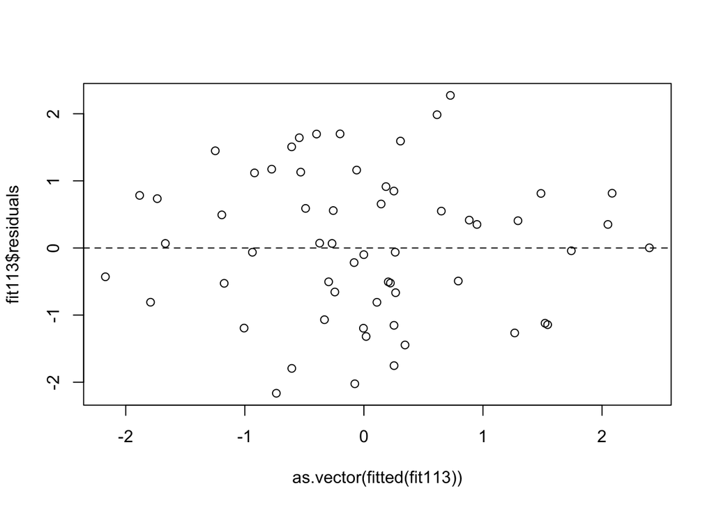

```r
plot(as.vector(fitted(fit113)), fit113$residuals)
abline(h = 0, lty = 2)
```

There appears to be no violation of constant variance.

###### b. The normality assumption (graphically).

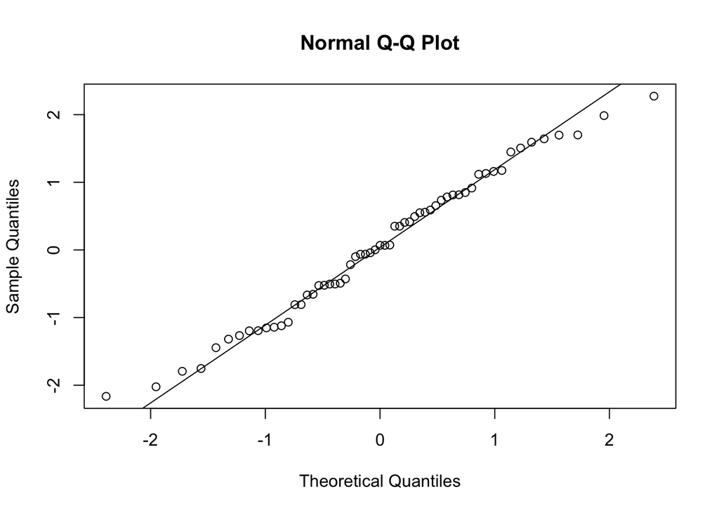

```r
qqnorm(fit113$residuals)
qqline(fit113$residuals)
```

Does not appear to be a violation of normality.

###### c. The independence assumption (graphically & statistically).

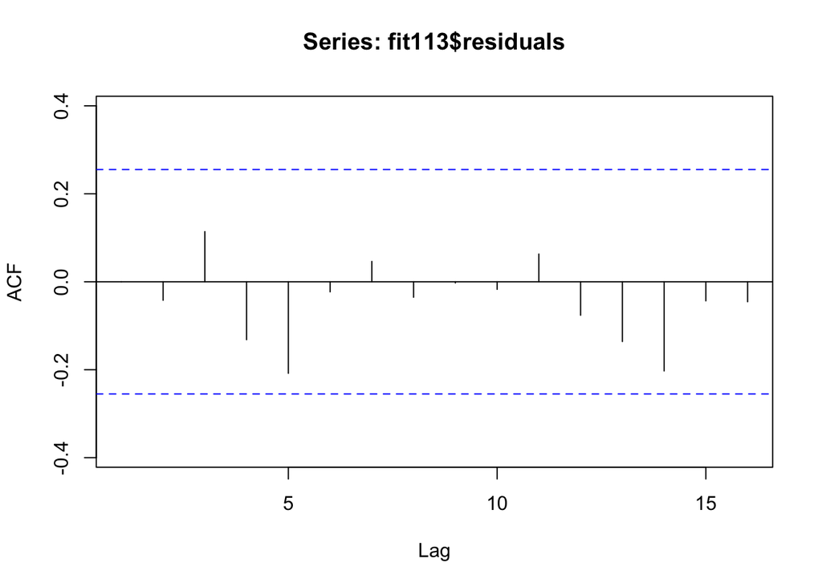

```r
Acf(fit113$residuals) #nothing significant here, independence is okay
```

```r
Box.test(fit113$residuals, type = "Ljung-Box") #p-value is insignificant therefore we can retain the null hypothesis that the correlations among the residuals are zero, therefore the model is sufficient.
```

```
##
##  Box-Ljung test
##
## data:  fit113$residuals
## X-squared = 0.48654, df = 1, p-value = 0.4855
```

##### 10. Forecast the next few observations and display this graphically.

```r
new.values <- forecast(fit113, 10, level = c(60, 80, 95))
new.values
```

```
##      Point Forecast      Lo 60      Hi 60     Lo 80     Hi 80     Lo 95
## 1972     -1.2385887 -2.1638902 -0.3132872 -2.647562 0.1703843 -3.393427
## 1973      0.6307069 -0.5203999  1.7818137 -1.122104 2.3835176 -2.049986
## 1974     -0.5712190 -1.7225350  0.5800969 -2.324348 1.1819102 -3.252399
## 1975      0.6305391 -0.5206302  1.7817084 -1.122367 2.3834450 -2.050299
## 1976     -0.5710513 -1.7224297  0.5803271 -2.324276 1.1821730 -3.252376
## 1977      0.6303714 -0.5208604  1.7816032 -1.122630 2.3833725 -2.050612
## 1978     -0.5708836 -1.7223244  0.5805572 -2.324203 1.1824357 -3.252354
## 1979      0.6302038 -0.5210905  1.7814980 -1.122892 2.3833000 -2.050925
## 1980     -0.5707160 -1.7222192  0.5807872 -2.324130 1.1826983 -3.252332
## 1981      0.6300362 -0.5213205  1.7813929 -1.123155 2.3832274 -2.051238
##          Hi 95
## 1972 0.9162496
## 1973 3.3113995
## 1974 2.1099607
## 1975 3.3113774
## 1976 2.1102739
## 1977 3.3113552
## 1978 2.1105869
## 1979 3.3113330
## 1980 2.1108998
## 1981 3.3113108
```

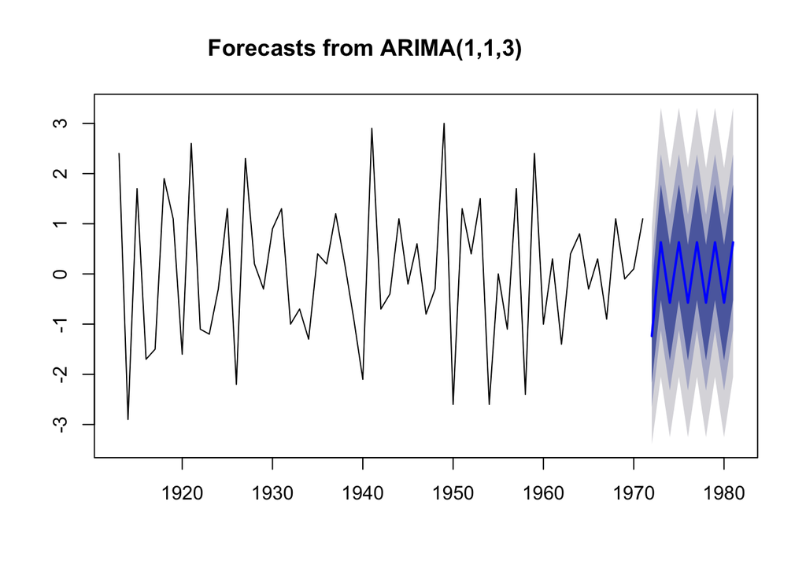

```r
plot(new.values)
```

The next ten predicted observations appear to be highly volatile.

##### 11. How will the weather change in New Haven Connecticut over the next few years?

Temperature changes are quite volatile going forward, which may be attributed to seasonality changes.

#### The brobs.csv dataset; this dataset describes the monthly armed robberies in Boston.

Hint #1: Use the following commands to read the dataset correctly and create a time series object: brobs = read.csv(“07brobs.csv”) brobs = ts(brobs[119, 2], start = 1966, frequency = 12) Hint #2: Comment on why you might want to log transform this data before proceeding with the ARIMA procedure.

```r
brobs = read.csv('07brobs.csv')
brobs = ts(brobs[-119, 2], start = 1966, frequency = 12)
```

##### 1.Plot the original time series

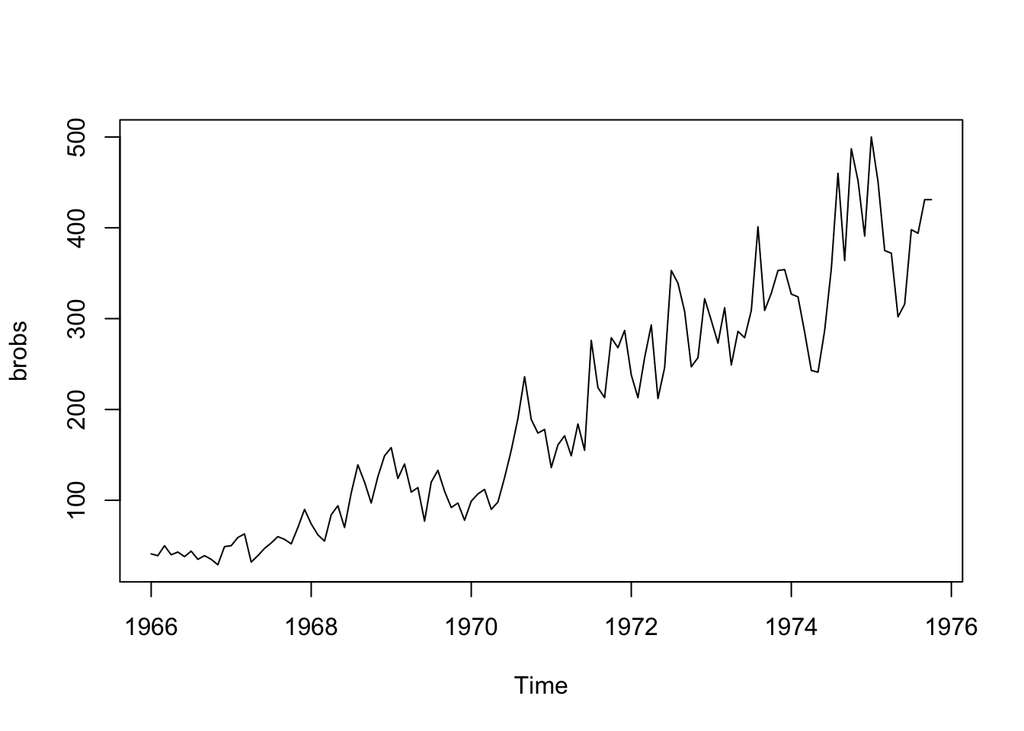

```r
plot(brobs)
```

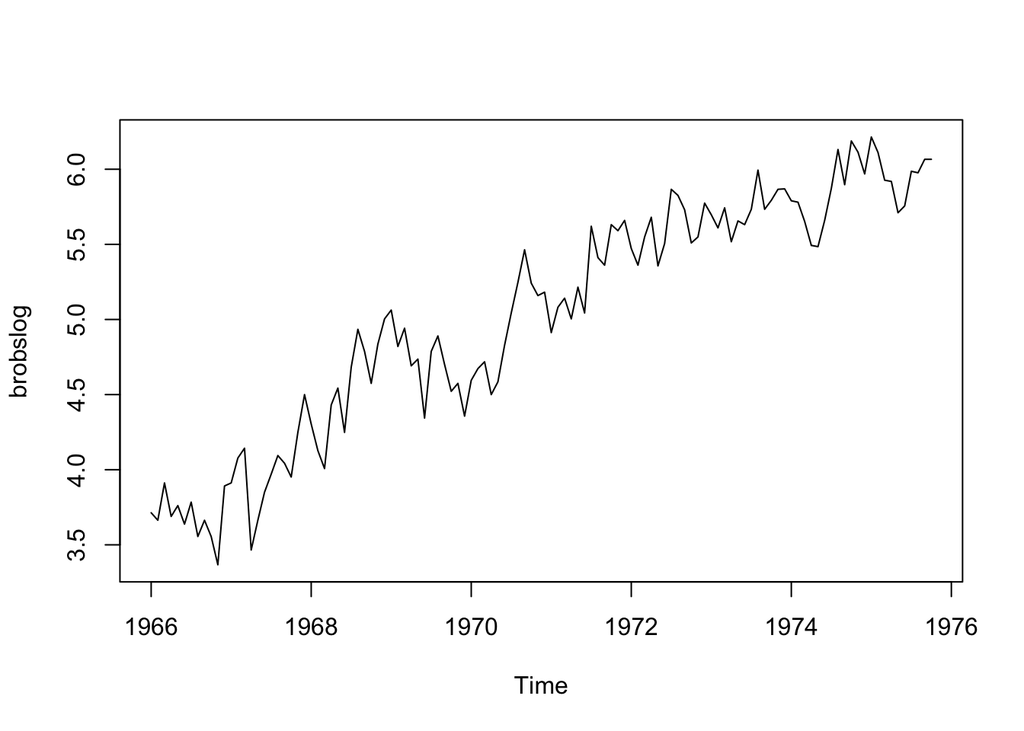

```r
# The plot appears to show minor exponential growth of the data over time, therefore it might be a good idea to log transform the data.

brobslog <- log(brobs)
plot(brobslog)
```

```r
# the plot of the logged set appears to be more linear in nature
```

##### 2.Determine the estimated number of differences necessary to make the time series stationary. If non-stationary, plot the differenced time series.

```r
ndiffs(brobslog)
```

```
## [1] 1
```

```r
brobslogDif <- diff(brobslog, differences = 1)
ndiffs(brobslogDif)
```

```
## [1] 0
```

d = 1 differentiated model results in ndiffs = 0, will continue with the first differentiated model.

##### 3.Run the Augmented Dicky-Fuller test and interpret the results. If necessary, return to part 2.

```r
adf.test(brobslogDif)
```

```
##
##  Augmented Dickey-Fuller Test
##
## data:  brobslogDif
## Dickey-Fuller = -6.0168, Lag order = 4, p-value = 0.01
## alternative hypothesis: stationary
```

Yielding a significant p-value; move forward without further differencing.

##### 4.Plot the autocorrelation and partial autocorrelation functions to determine intial values of p & q.

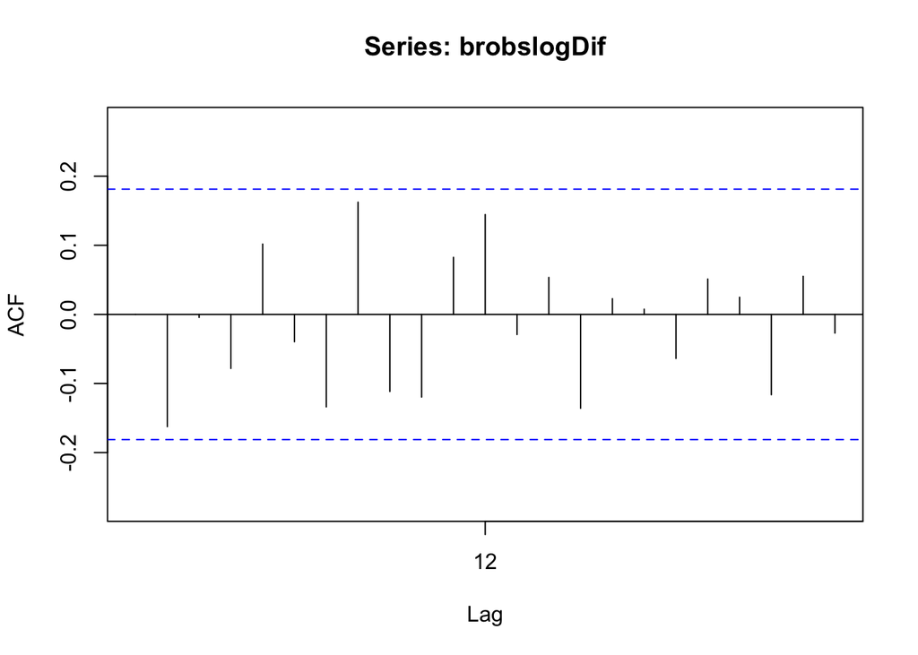

```r
Acf(brobslogDif)
```

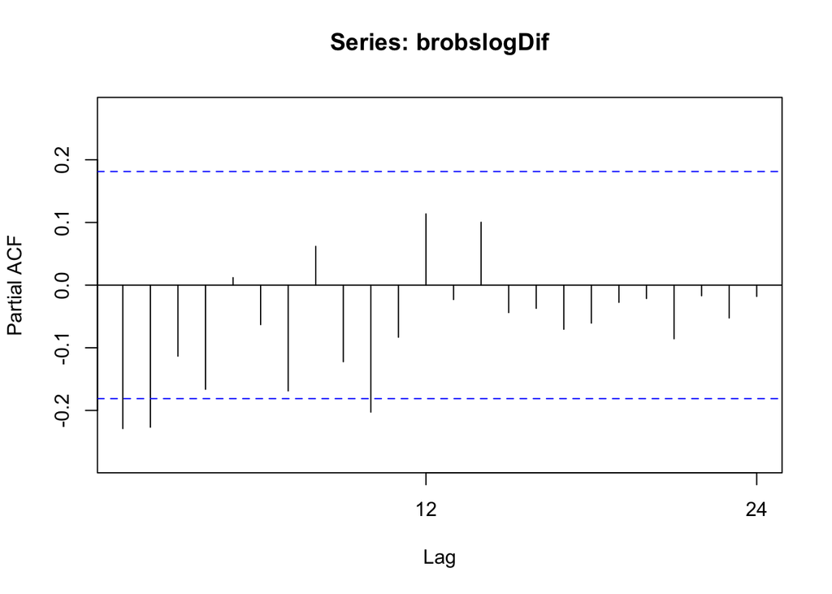

```r
Pacf(brobslogDif)
```

Let’s start with AR(2) and an MA(0); p = 2, q = 0 initially.